# What are the benefits and costs of using an interactive visualization over a static one?

by Justin Fu

Similar to a cassette player, a VHS recorder and a CD player, the following is a another dead electronic device, the overhead projector.

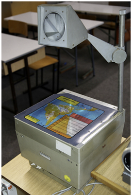

The legendary overhead projector was regularly used in classrooms and conferences to present text, charts, graphs and images to an entire classroom. Professors, teachers and presenters would use this machine to visualize their presentation to a larger audience. With the help of this visual aid, they could teach, educate and share their journey on all sorts of topics. These days, kids growing up are in a completely different world than it was only 25 to 30 years ago. If you were to show teenagers or kids a photo of the overhead projector, most likely they will not have a single clue.

During all this time that has gone by, data and visualizing data has always been around. The question at hand is, whether or not we should still be using visualizations that existed 25-30 years ago?

Today, in the year 2021, we are in an another era. This new generation of kids and young adults all around us grew up in the information age where everything travels fast. Not only fast, but also visually appealing enough keep them from moving on to the next TikTok video or messaging app.

In the past and even present, the standard for visualizing data like age demographics would be static images of line charts, area charts, bar charts, maps, etc. Below is one example of a barchart of Canadian demographic trends.

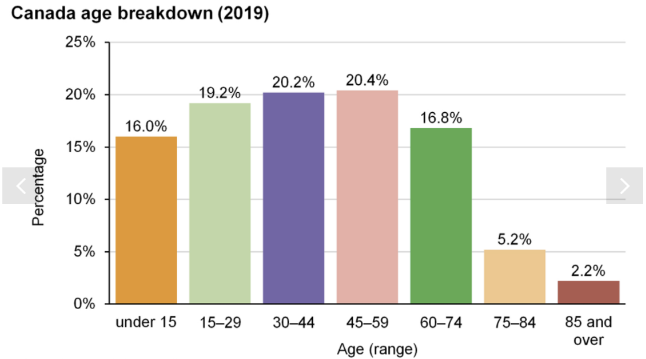

[Image Source](https://www.britannica.com/place/Canada/Demographic-trends)

Static data visualizations are still used today for good reason. The following are some of the pros and cons to using static visualizations:

| Pros | Cons |
| --- | --- |
| - quick and easy to build or make | - less of a wow factor compared to interactive visualizations |
| - data tools often include static visualizations in their toolsets (ex. Microsoft Excel) | - may need multiple static visualizations to tell a story |
| - easily interpreted | - there are limitations to how much data you can display |

Table 1. Advantages and disadvantages of static visualizations

The new standard for visualizing data goes beyond that of static visualizations. Consumers of data can not only just look at the visualizations, but they can also interact with it. By providng a user with an interactive visualization, they become part of the data. They are the actor that brings the story to the next step as they decompose complex and multi-level data into a single interactive data visualization.

[figure not shown]

Source: https://www.populationpyramid.net/canada/2020/

An example of an interactive visualization of age demographics can be seen above. They can interact with the story being told using the interactive visualization that would normally take many static visualizations to replicate. Users can click on different years to see how the demographics have changed over time and switch between countries. This can be all done while tracking how the population has grown over time. You can imagine how many static visualizations this would take to convey the same story.

Just like everything else, there are also pros and cons to using these interactive visualizations.

| Pros | Cons |
| --- | --- |
| - can tell complex stories with interactive visualizations that may normally take multiple static visualizations to communicate | - although improving everyday, there is a learning curve and more time needed to make interactive visualizations |
| - allowing users to interact with the visualizations also makes them part of the story | - if the design of the visualization isn't done properly, it may be worse than a static visualization |
| - a wow factor when the interactive visualizations are designed and built properly |  |

Table 2. Advantages and disadvantages of interactive visualizations

In a nutshell, to communicate data in this information age has never been better. Static and interactive visualizations are not competing with each other, but instead complementing each other. Depending on the data story, the resources and the time you have, you may decide to use one, the other or both together. With the addition of interactive visualizations in your toolbox, it will only enhance your ability to communicate and tell data stories to the world around us.